# 奇异值分解 singular value decomposition SVD

#### 林伯威

## SVD的数学基础

#### 《大数据分析》P48-49

### 定理3.1.1（矩阵对角化定理）

实方阵$S_{m\times m}$有m个线性无关的特征向量，则存在特征分解$S=U\Lambda U^{-1}$，其中$U=(\vec{u_1},\vec{u_2},...,\vec{u_m})$，$\Lambda=diag(\lambda_1,\lambda_2,...,\lambda_m)$，$\vec{u_i}$为S的特征向量，$\lambda_i$为$S$的特征值，$\lambda_i \ge \lambda_{i+1}$。

$$S\vec{u_i}=\lambda_i\vec{u_i}$$$$SU=S(\vec{u_1},\vec{u_2},...,\vec{u_m})=(\lambda_2\vec{u_1},\lambda_2\vec{u_2},...,\lambda_m\vec{u_m})=(\vec{u_1},\vec{u_2},...,\vec{u_m})diag(\lambda_1,\lambda_2,...,\lambda_m)$$$$SU=U\Lambda$$

### 定理3.1.2（对称对角化定理）

实对称方阵$S_{m\times m}$有m个线性无关的特征向量，则存在对称对角化分解$S=Q\Lambda Q^{-1}$，其中$Q$的每列都是互相正交且归一的特征向量，$Q^{-1}=Q^T$。

### 定理3.1.3

矩阵$C_{m\times n}$的秩为$r$，则存在奇异值分解$C=U_{m\times r}\Sigma_{r\times r} {V^T} _{r\times n}$，且

(1)$CC^T$的特征值$(\lambda_1,\lambda_2,...,\lambda_r)$等于$C^TC$的特征值；

(2)左奇异矩阵$U$是$CC^T$的特征向量的矩阵，右奇异矩阵$V$是$C^TC$的特征向量的矩阵，特征向量均为互相正交且归一的；

(3)$\Sigma=diag(\sigma_1,\sigma_2,...,\sigma_r)$，$\sigma_i=\sqrt{\lambda_i}$为奇异值，$\sigma_i \ge \sigma_{i+1}$。

$$C=\sum_{i=1}^r\sigma_iu_iv_i^T$$$$C=U_{m\times m}\Sigma_{m\times n} {V^T} _{n\times n}$$

## 特征值与奇异值

（对复数矩阵不了解，故都在实数矩阵范围内讨论）

**·**任意矩阵都有奇异值，但只有方阵有特征值。

**·**奇异值都是非负的，特征值可正可负可零。

**·**奇异值和特征值相等的矩阵是半正定矩阵。

https://www.zhihu.com/question/358795709

**·**矩阵的奇异值与特征值有什么相似之处与区别之处？

https://www.zhihu.com/question/19666954

**·** 矩阵的左奇异向量依次是样本方差最大的方向，奇异值的平方是对应方向的方差乘样本数量。

（$u_1$是方差最大的方向，$u_2$是正交与$u_1$的方差最大的方向，……）

```python
U, SIG, V = linalg.svd(matrix(C))
U_ = 1/n * U * matrix(np.diag(SIG * SIG))
```

$$U=\begin{bmatrix}-0.99997&-0.00713\\ -0.00713&0.99997\\\end{bmatrix}$$

$$\Sigma=diag(301.33234,198.77136)$$

$$U\_=\begin{bmatrix}-9.07989&-0.02817\\ -0.06475&3.95090\\\end{bmatrix}$$

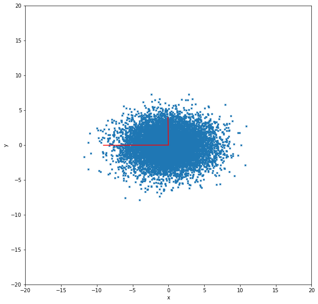

## python的svd

### 接口不统一

### numpy.linalg

返回$U$和$V^T$为方阵，$\Sigma$为长度$min\{m,n\}$的向量

```python
from numpy import matrix, linalg
C = matrix([[2,4,0],[1,3,0],[0,0,0],[0,0,0]])
U, SIG, VT = linalg.svd(C)
```

$$C=\begin{bmatrix}2&4&0\\ 1&3&0\\ 0&0&0\\ 0&0&0\\\end{bmatrix}$$

### numpy.linalg

返回$U$和$V^T$为方阵，$\Sigma$为长度$min\{m,n\}$的向量

$$U=\begin{bmatrix}-0.81742&-0.57605&0.0&0.0\\ -0.57605&0.81742&0.0&0.0\\ 0.0&0.0&1.0&0.0\\ 0.0&0.0&0.0&1.0\\\end{bmatrix}$$

$$\Sigma=diag(5.46499,0.36597,0.00000)$$

$$V^T=\begin{bmatrix}-0.40455&-0.91451&-0.0\\ -0.91451&0.40455&0.0\\ 0.0&0.0&1.0\\\end{bmatrix}$$

### scipy.sparse.linalg

稀疏矩阵svd

需要输入保留的奇异值个数$k\in[1,min(A.shape))$，默认6

###### if k <= 0 or k >= min(n, m): raise ValueError()

返回$U$和$V^T$不为方阵，$\Sigma$为长度k的向量，$U$、$V^T$和$\Sigma$均为倒序

```python
import scipy.sparse.linalg as linalg
import scipy.sparse as sparse
C = sparse.coo_matrix(([2,4,1,3],[[0,0,1,1],[0,1,0,1]]), (4,3), dtype=float)
U,SIG,VT = linalg.svds(C, 2)
```

$$C=\begin{bmatrix}2.0&4.0&0.0\\ 1.0&3.0&0.0\\ 0.0&0.0&0.0\\ 0.0&0.0&0.0\\\end{bmatrix}$$

### scipy.sparse.linalg

稀疏矩阵svd

需要输入保留的奇异值个数$k\in[1,min(A.shape))$，默认6

###### if k <= 0 or k >= min(n, m): raise ValueError()

返回$U$和$V^T$不为方阵，$\Sigma$为长度k的向量，$U$、$V^T$和$\Sigma$均为倒序

$$U=\begin{bmatrix}-0.57605&-0.81742\\ 0.81742&-0.57605\\ 0.0&0.0\\ 0.0&0.0\\\end{bmatrix}$$

$$\Sigma=diag(0.36597,5.46499)$$

$$V^T=\begin{bmatrix}-0.91451&0.40455&-0.00000\\ -0.40455&-0.91451&0.0\\\end{bmatrix}$$

## 主成分分析 principal components analysis PCA

#### 课件《模式识别与机器学习：无监督学习——降维》，郭嘉丰

### 线性降维的一般形式

**·**数据点 $X=(x_1,x_2,...,x_m)\in R^{d\times m}$

**·**新空间的数据点 $Z=(z_1,z_2,...,z_m)\in R^{d'\times m}$

**·**选择$d'$方向向量$w_1$，$w_2$，...，$w_{d'}$

$$W=(w_1,w_2,...,w_{d'})\in R^{d\times d'}$$

**·**将$x$投影到新空间 $z=W^Tx$（训练集为$Z=W^TX$）

如何选择$W$?

### PCA 目标函数1：最小化重建误差

**·**假定$\Vert w_i\Vert=1$，$w_i^Tw_j=0(i\neq j)$，为新的坐标系

**·**$W$用在两个函数中：

编码：$z_i=W^Tx_i$，$z_{ij}=w_j^Tx_i$

解码：$x_i'=Wz_i=\sum_{j=1}^{d'}z_{ij}w_j$

**·**我们希望重建误差$\Vert x - x'\Vert$尽可能小

**·**目标：最小平方重建误差和

$$\min_{W\in R^{d\times d'}}\sum_{i=1}^m\Vert x_i - Wz_i\Vert^2$$

### PCA 目标函数1：推导

$$\sum_{i=1}^m\Vert x_i - Wz_i\Vert^2\\ =\sum(x_i^Tx_i+z_i^TW^TWz_i-2z_i^TW^Tx_i)\\ =-\sum z_i^Tz_i +{const}\\ =-tr(Z^TZ)\\ =-tr(ZZ^T)\\ =-tr(W^TXX^TW)$$

### PCA 目标函数2：最大化方差

**·**目标是捕捉数据的内在变化

**·**中心思想: 寻找一个方向向量，使得数据投影到其上后方差最大

**·**如果能找到，继续寻找下一个方向向量，该向量正交于之前的方向向量，并且数据方差最大

**·**如果足够幸运，我们能够找到一些这样的方向向量，称为主成分，它们可以用来精确的描述数据

**·**最大化样本投影的方差（假定样本中心化了）

$$\max \sum_i z_i^Tz_i=\max_w tr(W^TXX^TW)$$

### PCA 目标函数计算

**·**寻找$W \in R^{d\times d'}$使得： $$\max_Wtr(W^TXX^TW)$$ $$s.t.W^TW=1$$

**·**Lagrange方法：

引入Lagrange因子$\lambda_i,1 \le i \le d$ 得到Lagrange方程：（？） $$L=tr(W^TXX^TW)-\sum_{i=1}^d\lambda_i(w_i^Tw_i-1)$$

矩阵迹的性质$\frac{\partial tr(WAW^T)}{\partial W}=2WA,A=A^T$

令$\frac{\partial L}{\partial W^T}=0$，那么$XX^TW=\lambda W$

$W$是$XX^T$的特征向量

### PCA 目标函数计算（偏导注释）

$$L=tr(W^TXX^TW)-\sum_{i=1}^d\lambda_i(w_i^Tw_i-1)$$$$W^T=(w_1,w_2,...,w_{d'})^T$$$$\frac{\partial \lambda_i(w_i^Tw_i-1)}{\partial w_i^T}=2\lambda_iw_i^T$$$$=>\frac{\partial \sum \lambda_i(w_i^Tw_i-1)}{\partial W^T}=(2\lambda_1w_1,2\lambda_2w_2,...,2\lambda_{d'}w_{d'})^T\\ =2\lambda W^T$$$$=>\frac{\partial L}{\partial W^T}=2W^TXX^T-2\lambda W^T=0$$$$=>W^TXX^T=\lambda W^T$$$$=>XX^TW=\lambda W$$

### PCA 目标函数计算（取最大特征值注释）

$$X=U\Sigma V^T$$$$XX^T=U{\Sigma\Sigma^T}U^T$$$$W=(u_{p_1},u_{p_2},...,u_{p_{d'}})$$$$设A=W^TU=(a_1,a_2,...a_r)=(W^Tu_1,W^Tu_2,...,W^Tu_r)$$$$有a_i=W^Tu_i=(u_{p_1},u_{p_2},...,u_{p_{d'}})^Tu_i$$$$=>a_i^Ta_i={I(i\in \{p_1,p_2,...,p_{d'}\})}$$$$=>{tr}(W^TXX^TW)={tr}({A\Sigma\Sigma^TA^T})={tr}(\sum \sigma_i^2a_ia_i^T)\\ =\sum \sigma_i^2{tr}(a_ia_i^T)\\ =\sum \sigma_i^2a_i^Ta_i\\ =\sum \sigma_i^2{I(i\in \{p_1,p_2,...,p_{d'}\})}$$

### 求解PCA

**·**输入：$X=(x_1,x_2,...,x_m)$，低维空间的维度：$d'$

**·**算法过程：

$x_i=x_i-\bar {x_i}$

对${XX^T}$做特征分解

###对$X$做奇异值分解

$d'$个最大特征值对应的特征向量$(w_1,w_2,...,w_{d'})$

###$d'$个最大奇异值对应的左奇异向量$(u_1,u_2,...,u_{d'})$

**·**输出:$W=(w_1,w_2,...,w_{d'})$

###输出:$U'=(u_1,u_2,...,u_{d'})$

### 参数$d'$

**·**用户指定

**·**利用简单分类器（如kNN）通过交叉验证方式选择

**·**使用重建阈值$\frac{\sum_{i=1}^{d'}\lambda_i}{\sum_{j=1}^d\lambda_j}\ge t$（如方差的85%）

### PCA与K-L的区别

（https://blog.csdn.net/oldmonkeyyu_s/article/details/45766543）

**·**PCA的变换矩阵是协方差矩阵，K-L变换的变换矩阵可以有很多种（二阶矩阵、协方差矩阵、总类内离散度矩阵等等）。

**·**当K-L变换矩阵为协方差矩阵时，等同于PCA。

## 隐性语义索引（LSI）/潜在语义分析（LSA） Latent semantic Indexing/Latent semantic analysis

#### https://wenku.baidu.com/view/cb373a1c5f0e7cd184253634.html

#### https://blog.csdn.net/hlang8160/article/details/81054232

### 词项-文档矩阵($X$)

**·**描述词与文档关系的稀疏矩阵，行代表词，列代表文档。

**·**矩阵元素可以是词袋、词频、TF-IDF等。

### 奇异值分解$X=U\Sigma V^T$

**·**$\Sigma$：语义维度的重要性，可以被称为主题topic或概念concept。

**·**$U$词项-概念矩阵，行代表词，列代表概念，行向量相似度可以作为词的相似度。

**·**$V^T$概念-文档矩阵，行代表概念，列代表文档，列向量相似度可以作为文档的相似度。

### 比较文档相似度可以使用的五个矩阵

**·**$X=U\Sigma V^T$：原始矩阵，词项-文档矩阵；太大，噪音，稀疏（近义词没有相似度）。

**·**$V^T=\Sigma^{-1}U^TX$：概念-文档矩阵；大。

**·**$V'^T=\Sigma'^{-1}U'^TX$：概念-文档降维矩阵；通常见到的做文档相似度使用的矩阵。

**·**$Y=\Sigma'V'^T=U'^TX$：降维矩阵，PCA降维后得到的矩阵；不知道为什么不使用。

**·**$X'=U'\Sigma'V'^T=U'U'^TX$：还原矩阵，降维后还原到原始空间的矩阵；有见到博客引用一篇使用的文章，太大，不是稀疏矩阵。

## 在图像压缩中的应用

#### https://www.cnblogs.com/endlesscoding/p/10033527.html

cat.size = (600, 600)

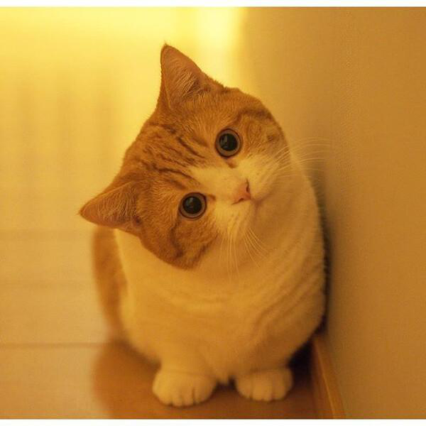

cat.size = (600, 600)

奇异值平方的比例

80%

85%

90%

维数

22

42

80

无中心化

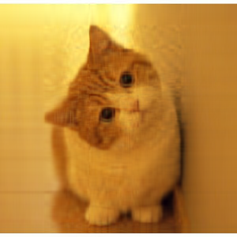

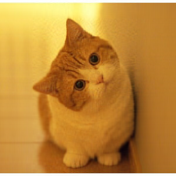

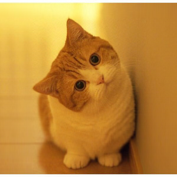

维数

67

96

140

中心化

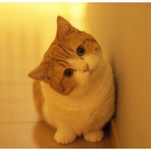

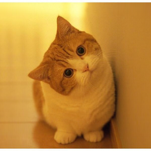

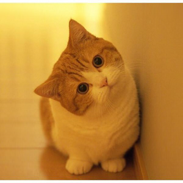

cat.size = (600, 600)

维数

40

80

120

比例

0.8474780394804808

0.9007838581542902

0.9319761422899889

无中心化

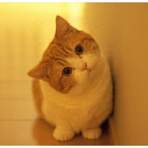

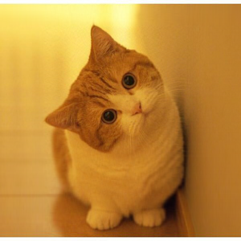

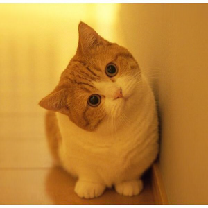

比例

0.7317424137153311

0.8253924854428133

0.8803701489826138

中心化

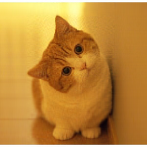

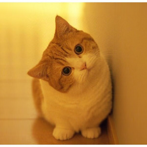

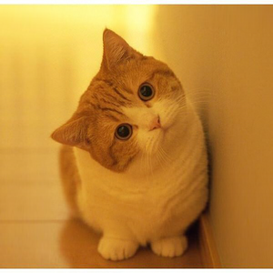